# **secr** simulations

## Results

First check the mean sample sizes for each scenario

```
##   CVlambda0 CVsigma2       n       r   nmov    dpa
## 1         0        0 109.010  85.756 49.754 1.4556
## 2       0.2        0 108.590  87.334 50.266 1.4627
## 3       0.4        0 105.772  90.432 51.046 1.4824
## 4       0.6        0 100.984  93.558 50.732 1.5027
## 5       0.8        0  96.746  97.770 51.388 1.5309
## 6         0      0.2 109.792  88.924 51.924 1.4723
## 7         0      0.4 108.204  94.724 57.412 1.5301
## 8         0      0.6 107.310 104.890 66.080 1.6155
## 9         0      0.8 105.566 117.686 76.964 1.7286
```

```
## Density
##   CVlambda0 CVsigma2 true.D nvalid    EST   seEST        RB     seRB    RSE  RMSE  rRMSE    COV
## 1         0        0   12.5    500 12.455 0.05558 -0.003622 0.004447 0.1098 1.242 0.0994 0.9520
## 2       0.2        0   12.5    500 12.285 0.06112 -0.017165 0.004889 0.1094 1.382 0.1106 0.9440
## 3       0.4        0   12.5    500 11.646 0.05823 -0.068345 0.004658 0.1093 1.556 0.1245 0.8980
## 4       0.6        0   12.5    500 10.779 0.05717 -0.137672 0.004574 0.1100 2.143 0.1714 0.6920
## 5       0.8        0   12.5    500  9.989 0.04903 -0.200902 0.003922 0.1107 2.740 0.2192 0.4540
## 6         0      0.2   12.5    500 12.299 0.05837 -0.016093 0.004669 0.1087 1.319 0.1055 0.9580
## 7         0      0.4   12.5    500 11.517 0.05617 -0.078608 0.004493 0.1079 1.594 0.1275 0.8960
## 8         0      0.6   12.5    500 10.620 0.05242 -0.150429 0.004194 0.1065 2.215 0.1772 0.6380
## 9         0      0.8   12.5    499  9.581 0.04970 -0.233549 0.003976 0.1059 3.123 0.2498 0.2625
## lambda0
##   CVlambda0 CVsigma2 true.lambda0 nvalid     EST     seEST       RB     seRB    RSE    RMSE  rRMSE    COV
## 1         0        0          0.1    500 0.10180 0.0006537  0.01801 0.006537 0.1497 0.01471 0.1471 0.9340
## 2       0.2        0          0.1    500 0.10409 0.0007136  0.04087 0.007136 0.1482 0.01646 0.1646 0.9260
```

[output cut: 18 more lines]

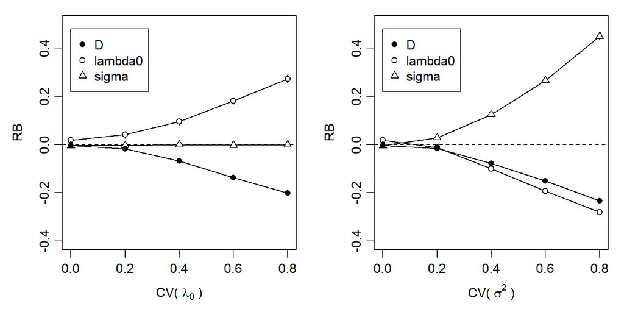

Relative bias of parameter estimates from null model given individual variation

## One-off

Run this code to obtain results for a single scenario (here CV(lambda0) = 0.6). Here we fit both a null model (lambda0~1) and a 2-class finite mixture model (lambda0~h2). The mixture model performed well in terms of bias (-0.4%) and confidence interval coverage (93%), with two caveats: not all datasets yielded estimates, and the precision of the estimates was greatly reduced (relative standard error increased from 0.11 to 0.30).

```r
source('../setup.R')
grid <- make.grid(nx = 8, ny = 8, spacing = 40, detector = "proximity")
poparg <- list(covariates = popn.covariates, lambda0 = 0.1, sigma = 20, CVlambda0 = 0.6, CVsigma2 = 0)
detarg <- list(detectpar = list(individual = TRUE))
fitarg <- list(
    list(detectfn = 'HHN', model = lambda0 ~ 1),
    list(detectfn = 'HHN', model = lambda0 ~ h2)
)
scen <- make.scenarios(D = 12.5, noccasions = 10, detectfn = 14,
    lambda0 = 0.1, sigma = 20, popindex = 1, fitindex = 1:2)
oneoff <- run.scenarios(nrepl = 100, scen, trapset = grid, pop.args = poparg,
    det.args = detarg, fit = TRUE, fit.args = fitarg, seed = 12345)
# select density estimates from output
Dstats <- select.stats(oneoff, 'D', c('estimate','SE.estimate', 'RB','RSE','COV'))
# reject estimates with extreme SE.estimate, and summarise
summary(validate(Dstats, 'SE.estimate', c(0.001,100), 'all'))$OUTPUT
```